# Лабораторная работа №1

#### Ни чётная, ни нечётная функция

$$f(t)=cos^3(t-\frac{3}{4})$$

```python
T4 = 2*np.pi
def not_even_odd_func(t):
    return (np.cos(t - 0.75))**3
```

В данном случае мы не можем сказать о занулении каких-то коэффициентов заранее, поэтому формула будет максимально общая

Получим коэффициенты Фурье с помощи программы при $n=\{0,1,2,3\}$

```python
printBeauty(compute_complex_fourier_coeffs(not_even_odd_func, 3, -T4, 2*T4))
printBeauty(compute_real_fourier_coeffs(not_even_odd_func, 3, -T4, 2*T4), float)
```

```
-0.0000+0.0000j
 0.2744+0.2556j
 0.0000+0.0000j
 0.0000+0.0000j
 0.0000-0.0000j
 0.2744-0.2556j
-0.0000-0.0000j

 0.0000 0.0000
 0.0000 0.0000
 0.5488 0.5112
-0.0000 0.0000
```

Построим графики частичных сумм при $n = \{1,2,3,4,5\}$

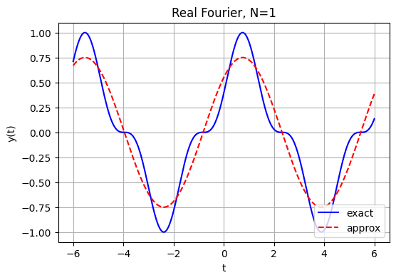

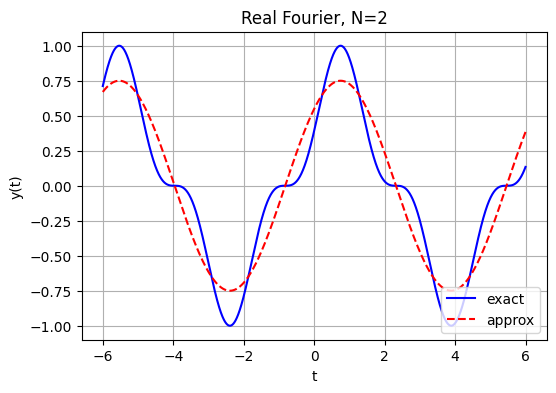

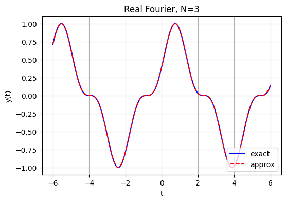

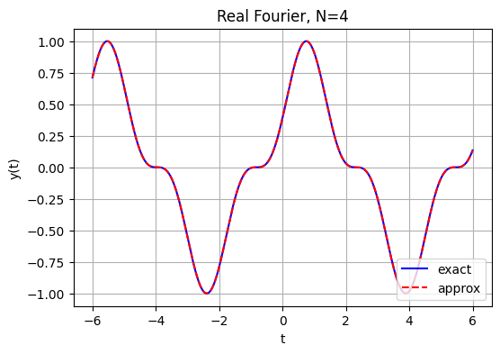

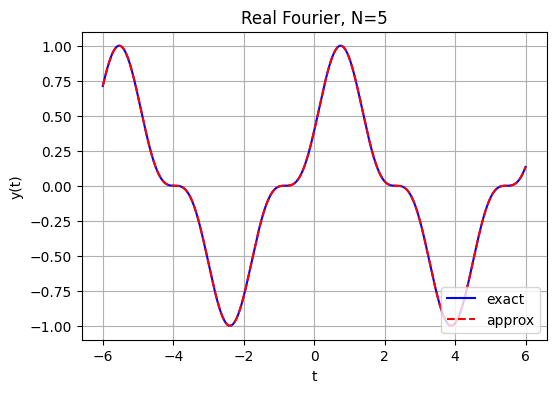

```python
plot_real_fourier(not_even_odd_func,t,[1,2,3,4,5],-np.pi, 2*np.pi)
```

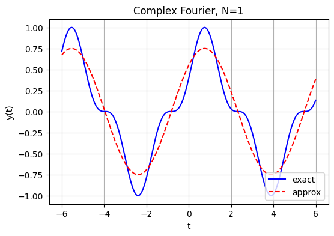

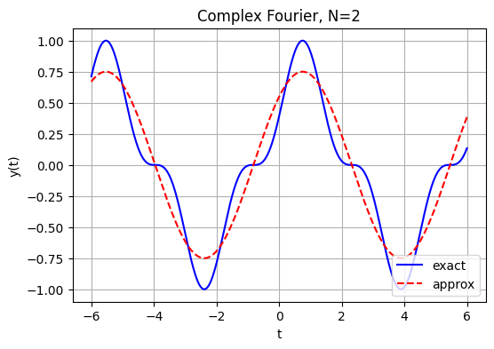

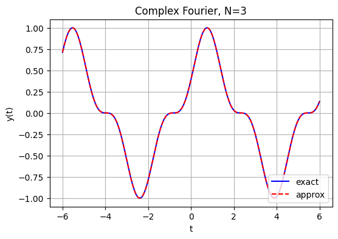

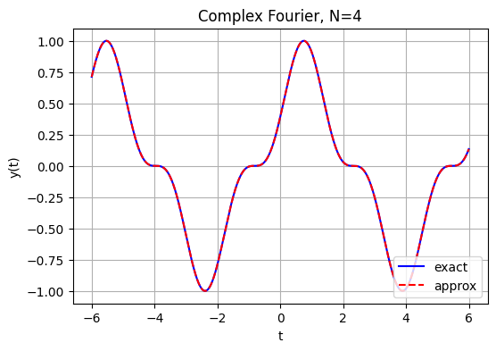

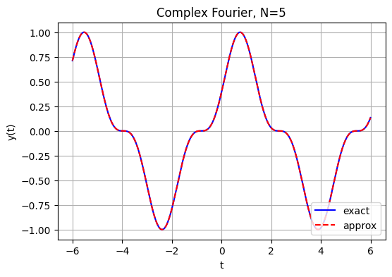

```python
plot_complex_fourier(not_even_odd_func,t,[1,2,3,4,5],-np.pi, 2*np.pi)
```

Можно заметить, что уже при $N=3$ мы хорошо (на глаз) смогли приблизиться к исходной функции, хотя вроде функция кажется сложно устроенной. Также снова подмечу, что приближение рядом Фурье в комплексной или вещественной форме здесь идентичны.

Как и с остальными функциями, давайте проверим равенство Парсеваля:

```python
T = 2*np.pi
h = -np.pi
for n in [1,2,3,7,8,10,20,50,100,200]:
    print(f"delta: {check_parseval(not_even_odd_func, t, h, T,n):.5f}")
```

```
N = 1 --> coeff 1.76715 and int 1.96350
delta: 0.19635
N = 2 --> coeff 1.76715 and int 1.96350
delta: 0.19635
N = 3 --> coeff 1.96350 and int 1.96350
delta: 0.00000
N = 7 --> coeff 1.96350 and int 1.96350
delta: 0.00000
N = 8 --> coeff 1.96350 and int 1.96350
delta: 0.00000
N = 10 --> coeff 1.96350 and int 1.96350
delta: 0.00000
N = 20 --> coeff 1.96350 and int 1.96350
delta: 0.00000
N = 50 --> coeff 1.96350 and int 1.96350
delta: 0.00000
N = 100 --> coeff 1.96350 and int 1.96350
delta: 0.00000
N = 200 --> coeff 1.98278 and int 1.96350
delta: 0.01928
```

[output not shown]

Зададимся числами $R,T>0$ и рассмотрим функцию $f: \mathbb{R}\rightarrow\mathbb{C}$ с периодом $T$, что...

$$ \begin{aligned} Re(f(t)) = \begin{cases} R, & t\in [-\frac{T}{8},\frac{T}{8}), \\ 2R - 8Rt/T, & t\in [\frac{T}{8},\frac{3T}{8}), \\ -R, & t\in [\frac{3T}{8},\frac{5T}{8}), \\ -6R + 8Rt/T, & t\in [\frac{5T}{8},\frac{7T}{8}), \end{cases} &&& Im(f(t)) = \begin{cases} 8Rt/T, & t\in [-\frac{T}{8},\frac{T}{8}), \\ R, & t\in [\frac{T}{8},\frac{3T}{8}), \\ 4R - 8Rt/T, & t\in [\frac{3T}{8},\frac{5T}{8}), \\ -R, & t\in [\frac{5T}{8},\frac{7T}{8}), \end{cases} \end{aligned} $$

```python
R = 10 ; T = 3
```

Тогда в нашем случае...

$$ \begin{aligned} Re(f(t)) = \begin{cases} 10, & t\in [-\frac{T}{8},\frac{T}{8}), \\ 20 - 80t/3, & t\in [\frac{T}{8},\frac{3T}{8}), \\ -10, & t\in [\frac{3T}{8},\frac{5T}{8}), \\ -60 + 80t/3, & t\in [\frac{5T}{8},\frac{7T}{8}), \end{cases} &&& Im(f(t)) = \begin{cases} 80t/3, & t\in [-\frac{T}{8},\frac{T}{8}), \\ 10, & t\in [\frac{T}{8},\frac{3T}{8}), \\ 40 - 80t/3, & t\in [\frac{3T}{8},\frac{5T}{8}), \\ -10, & t\in [\frac{5T}{8},\frac{7T}{8}), \end{cases} \end{aligned} $$

Зададим функцию программно через if-else

```python
def f(t):
    t = (t + T/8)%T - T/8

    if -T/8 <= t < T/8:
        real = R
        imag = 8*R*t/T
    elif T/8 <= t < 3*T/8:
        real = 2*R - 8*R*t/T
        imag = R
    elif 3*T/8 <= t < 5*T/8:
        real = -R
        imag = 4*R - 8*R*t/T
    elif 5*T/8 <= t < 7*T/8:
        real = -6*R + 8*R*t/T
        imag = -R

    elif 5*T/8 <= t < 7*T/8:
        real = -6*R + 8*R*t/T
        imag = -R
    return real + 1j*imag
# "векторизуем" кусочно-заданную функцию, чтобы потом использовать в других методах
# библиотеки numpy
ff = np.vectorize(f)
```

Построим параметрический график $f(t)$ в виде кривой на комплексной плоскости

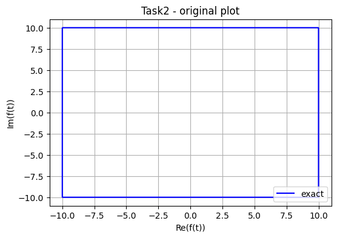

```python
# возьмём в качестве координаты X все возможные значения на периоде
X = np.linspace(-T/8, 7*T/8, 1000)
plot_task2_original(ff,X)
```

Посмотрим на частичные суммы Фурье для этого графика, $G_N(t) = \sum^N_{n=-N}c_ne^{i\omega_n t}$, где $\omega_n = 2\pi n / T$

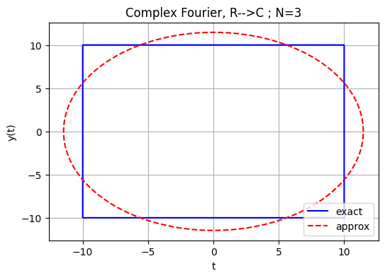

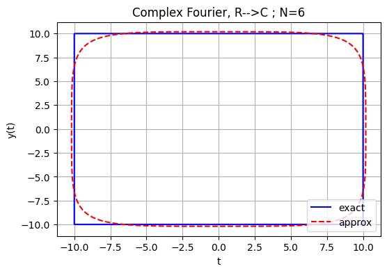

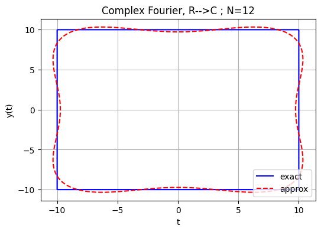

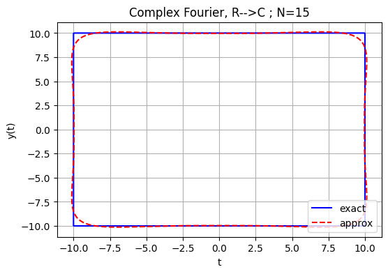

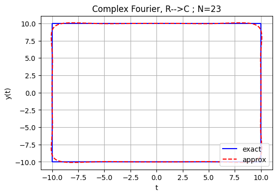

```python
plot_complex_plane_fourier(ff,X,[3,6,12,15,23,],-T, 2*T)
```

Вычислим для $n=\left\{0,1,2 \right\}$ вручную;

На всех кусках функция состоит из линейной и константной части, которая чередутся в зависимости от $t$, это немного упростит задачу вычисления "руками". $f(t)$ - кусочек функции

$$ \begin{aligned} c_n= \frac{1}{T}\int^{n+T}_n \bigg[f(t)e^{-i\omega_n t}\bigg]dt \end{aligned} $$

$$ \begin{aligned} c_n= \frac{1}{3}\int \bigg[f(t)e^{-i \frac{2 \pi t}{3}}\bigg]dt = \frac{1}{3}\bigg[\int^{21/8}_{15/8} (-60+80t/3-10i)e^{-i \frac{2 \pi t}{3}}dt \\ + \int^{15/8}_{9/8} (-10+i(40-80t/3))e^{-i \frac{2 \pi t}{3}}dt \\ + \int^{9/8}_{3/8} (20-80t/3+10i)e^{-i \frac{2 \pi t}{3}}dt + \int^{3/8}_{-3/8} (10+i80t/3)e^{-i \frac{2 \pi t}{3}}dt \bigg] = \\ \int^{15/8}_{3/8}(-20/3+7t-6i)e^{-i \frac{2 \pi t}{3}}dt \end{aligned} $$

$$ \begin{aligned} c_{-3} \approx -0.109 \end{aligned} $$ $$ \begin{aligned} c_{-2} \approx 0.181 \end{aligned} $$ $$ \begin{aligned} c_{-1} \approx -0.278 \end{aligned} $$

$$ \begin{aligned} c_0 \approx 0.451 \end{aligned} $$ $$ \begin{aligned} c_1 \approx -0.921 \end{aligned} $$ $$ \begin{aligned} c_2 \approx 11.246 \end{aligned} $$ $$ \begin{aligned} c_3 \approx 1.225 \end{aligned} $$

Сравним посчитанные коэффициенты вручную с программой, $N=3$, и они хорошо сходятся

```python
printBeauty(compute_complex_fourier_coeffs(ff, 3,-np.pi, 2*np.pi))
```

```
-0.1091-0.0000j
 0.1814-0.0000j
-0.2781+0.0000j
 0.4507+0.0000j
-0.9211-0.0000j
11.2460+0.0000j
 1.2257-0.0000j
```

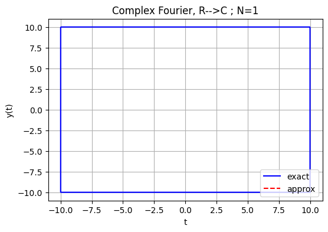

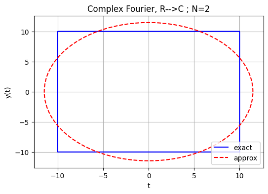

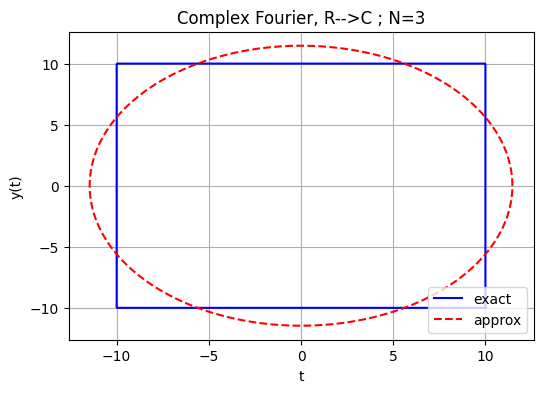

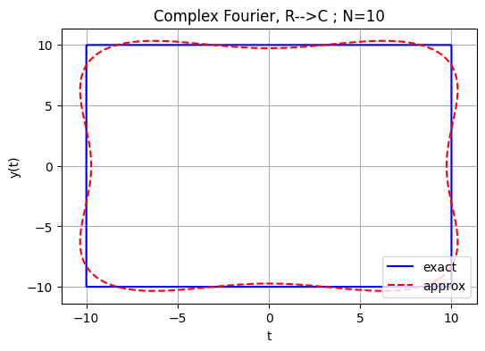

```python
plot_complex_plane_fourier(ff,X,[1,2,3,10], -T, 2*T)
```

Приближаемся гармониками, как и раньше, чётными и нечётными, но теперь они стали круговыми, вау!

Построим следующие графики в следующем порядке: $Ref(t)$, $Imf(t)$, $ReG_N(t)$, $ImG_N(t)$ для $N=\bigg\{1,2,3,10 \bigg\}$

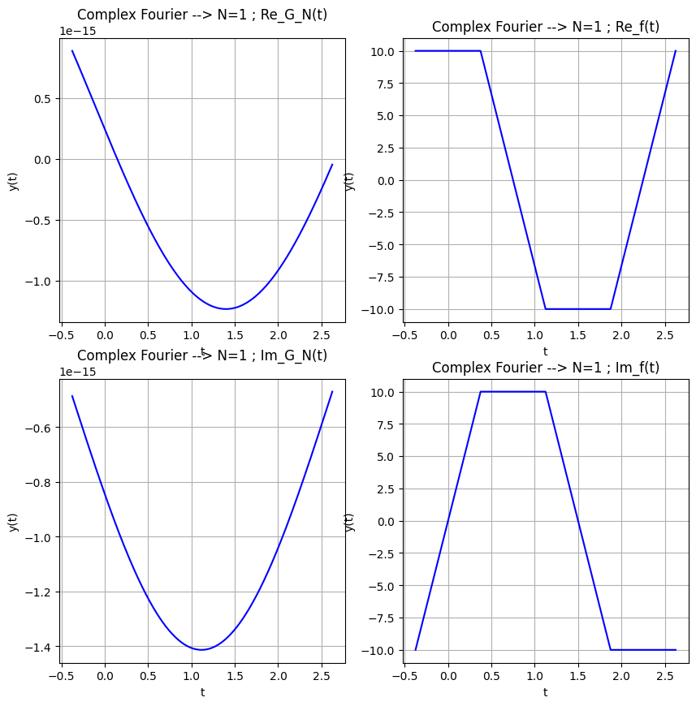

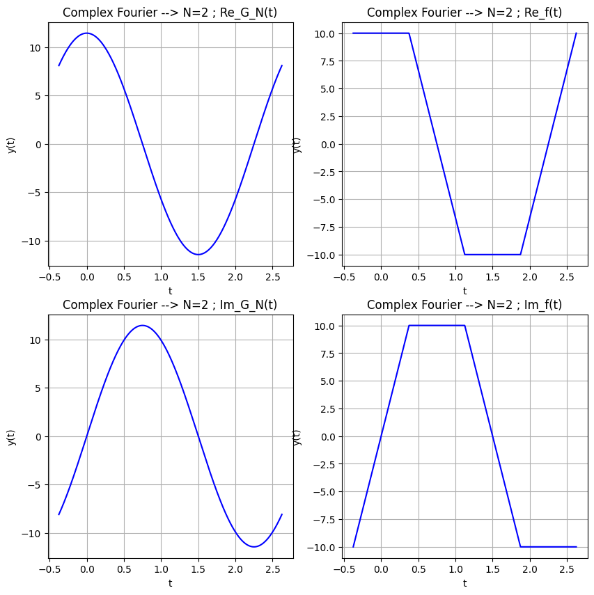

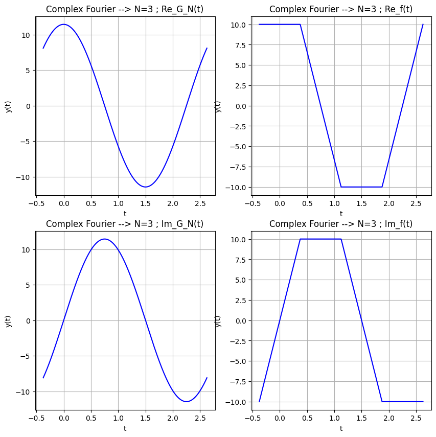

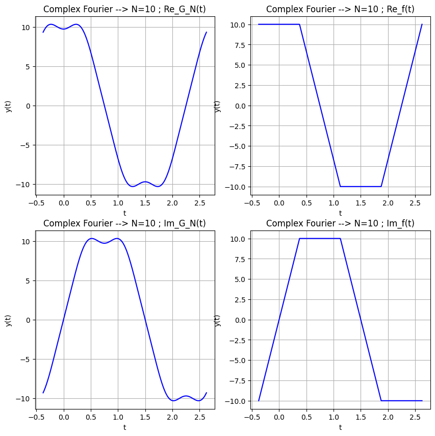

```python
plot_complex_plane_fourier_part(ff, X, [1,2,3,10], -T,2*T)
```

Проверим равенство парсеваля, в данном случае будем руководствоваться первой формулой, но придётся чуть поменять численное интегрирование под $\mathbb{C}$ случай

```python
def check_parseval_complex(func, x, h, T, N):
    # norm of the function
    INT = complex_quad(lambda t: abs(func(t))**2, -np.pi, np.pi)
    # squared coeffs
    COEFFS =  2*np.pi * compute_complex_fourier_coeffs_sum(func, N, h, T)
    print(f"N = {N} --> coeff {COEFFS:.5f} and int {INT:.5f}")
    return abs(INT - COEFFS)


T = 2*np.pi
h = -np.pi
for n in [10,20,50,100,200]:
    print(f"delta: {check_parseval_complex(ff, t, h, T,n):.5f}")
```

```
N = 10 --> coeff 837.62310 and int 837.75804+0.00000j
delta: 0.13495
N = 20 --> coeff 837.74093 and int 837.75804+0.00000j
delta: 0.01712
N = 50 --> coeff 837.75694 and int 837.75804+0.00000j
delta: 0.00110
N = 100 --> coeff 837.75790 and int 837.75804+0.00000j
delta: 0.00014
N = 200 --> coeff 841.14698 and int 837.75804+0.00000j
delta: 3.38894
```

| N | Delta | Норма | Сумма коэффициентов |
| --- | --- | --- | --- |
| 50 | 0.00110 | 837.75804 | 837.75694 |
| 100 | 0.00014 | 837.75804 | 837.75790 |
| 200 | 3.38894 | 837.75804 | 841.14698 |

Как можно заметить, при лучшем коэффициенте нам удаётся добится равенства до третьего знака

### Задание 3. Произвольный рисунок

Этот [таймкод](https://youtu.be/r6sGWTCMz2k?t=1258) из видео 3Blue1Brown даёт нам понять, что для начала нужно нарисовать в каком-нибудь редакторе замкнутую, допускающую самопересечения, кривую, а после найти способ сохранить её в хорошем .svg формате. Внутри такого файла будет xml разметка и можно с помощью питона спарсить её в path.

А что будет парсится то? и что такое Path? Эти вопросы уже больше относятся к формату **S**calable **V**ector **G**raphics, но если отвечать кратко, то внутри такого файла зашита обычная xml разметка, один из блоков которой содержит в себе информацию о примитивах, из которых "собирается" изображение. В нашем случае у нас такой частный случай изображения, что будут использоваться только кривые или линейные перемещения, поэтому файл можно спарсить в одну продолжительную кривую

Способов создать такое изображение, чтобы с него можно было спарсить - много, но я лично не хотел устанавливать новые программы, поэтому приведу основные шаги как это всё сделать в фотошопе.

1. Находим картинку, а после обводим её инструментом Pen в произвольном формате, главное, чтобы это была одна Фигура.
2. Делаем эту фигуру "смарт-объектом", после заходим внутрь неё и уже там пытаемся сделать экспорт проекта
3. Если у нас новая версия фотошопа, то возможно не будет формата SVG как выбора, тогда следуем этой [инструкции](https://www.bwillcreative.com/how-to-save-svg-files-in-photoshop/) и возвращаем себе её, экспортируем уже окончательное

[Вдохновитель инструкции](https://qna.habr.com/q/311434)

*N.B* - я не нашёл конвертеров $.PNG→.SVG$, которые понимают линии как сверхтонкие и, как следствие ,не делают двойную кривую, поэтому если не понимаете что такое "сверхтонкий абрис в coreldraw толщина в мм", то лучше просто сделайте всё в фотошопе, а не ищите конвертер

Также выяснил, что спарсить кривые, по которым строится исходное изображение в .svg можно с помощью питоновской библиотеки *svg.path*, однако с ней дальнейшая дружба у меня не сложилась и я воспользовался модулем *svgpathtools*

Теперь добавим немного смысловой нагрузки, ведь любое изображение из одной кривой можно представить в виде большой, но конечной(в смысле количества кусочков) кусочно-заданной функции, что сейчас мы и сделаем с помощью метода vectorize

```python
# файл можно найти в исходном коде
paths, attributes = svg2paths("Fig.svg")
path = paths[0]
# Create a lambda function for the path
path_func = np.vectorize(lambda t: path.point(t) * (1/16))
```

Убедимся, что мы смогли корректно импортировать кривые с файла, и наша функция действительно работаем сделаем график из точек на равномерном расстоянии друг от друга, так как пространство оси X здесь нормировано $[0;1]$, то его можно задать удобным образом. В качестве примера возьмём 150 точек

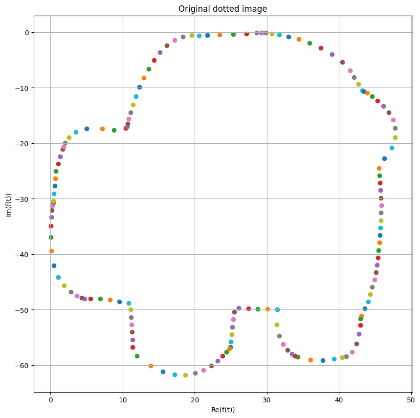

```python
x = np.linspace(0,1,150)

def plot_scatter(path):
  plt.figure(figsize=(10, 10))
  for t in x:
    path = path_func(t)
    plt.scatter(path.real, -path.imag)
  plt.xlabel('Re(f(t))')
  plt.ylabel('Im(f(t))')
  plt.title("Original dotted image")
  plt.grid()
  plt.show()

plot_scatter(path_func)
```

Очевидным становится, что каждая точка - просто комплексное число, а значит для такой функции можно применить идею из второго задания - ряд Фурье для комплексной функции...

Получим коэффициенты для частичное суммы при $N=3$

Отдельное внимание хочу уделить тому, что коэффициенты ищутся на промежутке интеграла от 0 до 1, до конца не выяснил почему, но возможно особенность импортированной функции, главное, что работает :)

```python
printBeauty(compute_complex_fourier_coeffs(path_func, 3, 0, 1))
```

```
 0.0800- 0.8339j
 1.3141+ 0.1137j
-1.0340+ 2.7876j
24.7979+32.6910j
 8.1614+24.5065j
-1.7982- 2.2044j
-0.1388- 1.3203j
```

Также придётся переопределить функции вычисления коэффициентов, потому что иначе график становится перевёрнутым по оси Y, вторая, так называемая особенность импорта...(просто два минуса добавить)

```python
def compute_complex_plane_fourier_coeffs(func, N, h,T):
    result = []
    for n in range(-N, N+1):
        cn = (1./T) * complex_quad(lambda t: func(t) * np.exp(-1j * 2 * np.pi * n * t / T), h, h+T)
        result.append(cn)
    return np.array(result)

def fit_func_by_fourier_series_with_complex_plane_coeffs(t, C, T):
    result = 0. + 0.j
    L = int((len(C) - 1) / 2)
    for n in range(-L, L+1):
        c = C[n+L]
        result +=  c * np.exp(1j * 2. * np.pi * n * t / T)
    return result

def G_N_complex(f, x,N, h,T):
    C = compute_complex_plane_fourier_coeffs(f, N, h,T)
    y_approx = fit_func_by_fourier_series_with_complex_plane_coeffs(x, C, T)

    return [[y.real for y in y_approx], [-y.imag for y in y_approx]]
```

```python
def plot_complex_plane_fourier(func, x, N, h, T):
    for i in N:
        G_N = G_N_complex(func, x, i, h,T)
        plt.figure(figsize = (10, 10))
        plt.plot(func(x).real, -func(x).imag, label='exact',color='blue')
        plt.plot(G_N[0], G_N[1], color='red', linestyle='dashed',label='approx')
        plt.title('Complex Fourier, R-->C ; ' + f"N={i}")
        plt.xlabel('t')
        plt.ylabel('y(t)')
        plt.legend(loc='lower right')
        plt.grid()
        plt.show()
```

Построим некоторые частичные суммы.... да, график действительно сходится!

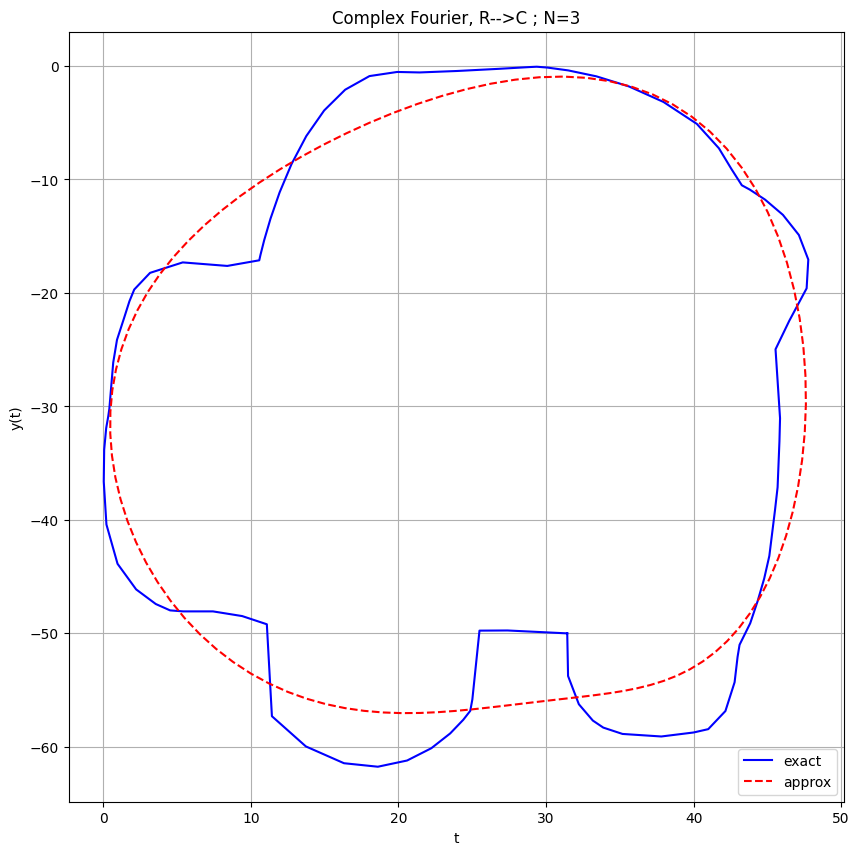

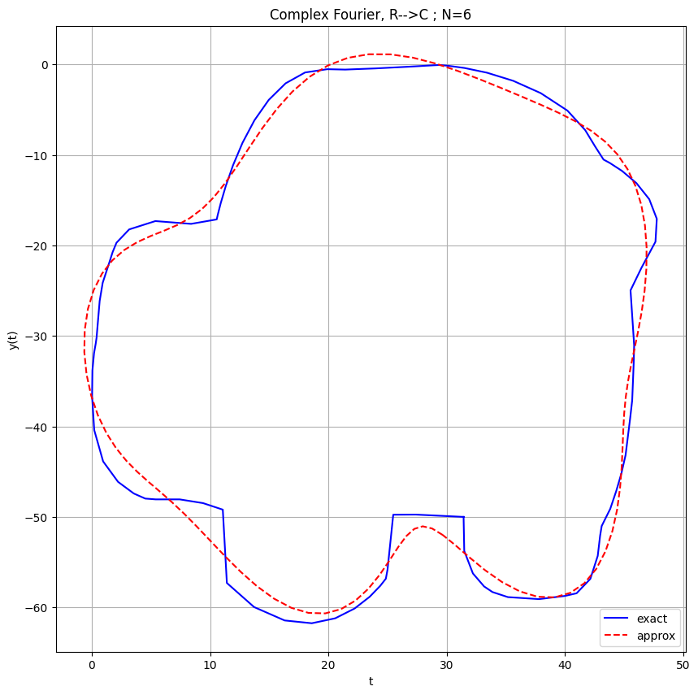

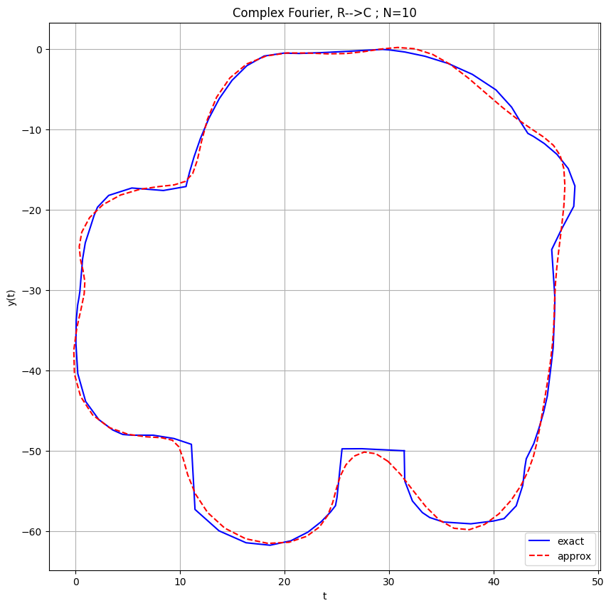

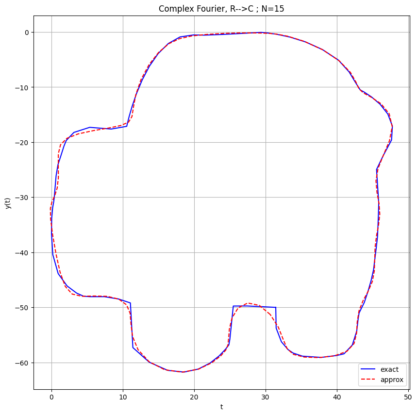

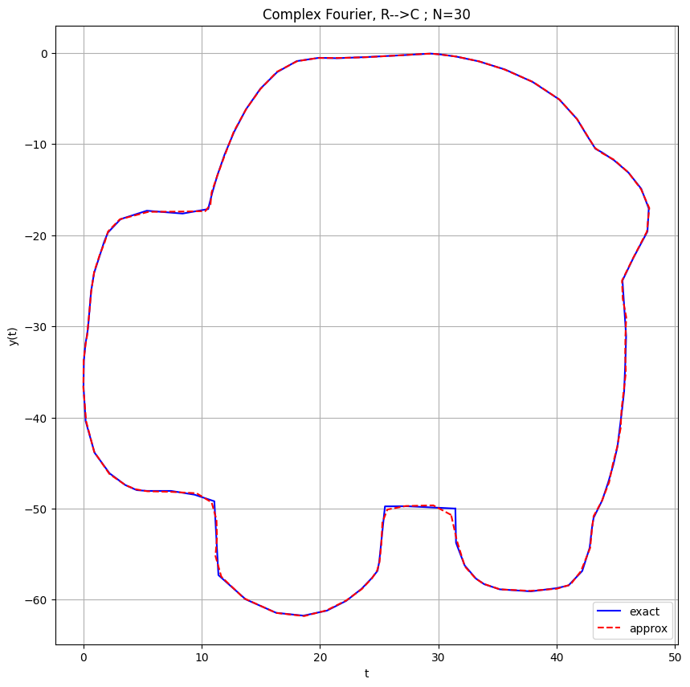

```python
x = np.linspace(0,1,100)
plot_complex_plane_fourier(path_func,x,[3,6, 10, 15,30],0, 1)
```

Сегодня я не нашёл в себе силы победить Manim и сделать красивую анимацию, но уж в следующий раз....

## Полезные ссылки

Здесь решил оставить некоторую часть всего добра, что помогало мне на протяжении лабы, по возможности к некоторым оставил свои комментарии

1. [Просто крутой интерактивный сайт](https://www.jezzamon.com/fourier/index.html)
2. [По поводу визуализации рядов Фурье](https://www.youtube.com/watch?v=Mm2eYfj0SgA)
3. [Много про разные виды Фурье, в том числе многомерные, с примерами кода вычисления через scipy](https://computationalmindset.com/en/mathematics/fourier-series-in-python.html#hdemo1)
4. [Ряды Фурье в блендере](https://skine.ru/articles/287505/)
5. [Ряды Фурье DFT отрисовка](https://dsp.stackexchange.com/questions/59068/how-to-get-fourier-coefficients-to-draw-any-shape-using-dft)
6. [Ряды Фурье и 3B1B - про идею появления](https://youtu.be/spUNpyF58BY?si=Tm-UgPmWUZvRV7pV)
7. [Ряды Фурье и 3B1B - про рисование](https://youtu.be/r6sGWTCMz2k?si=KE245VKw0Jn0-Qz1)